# Day 01

Joao Malato

Instituto de Medicina Molecular & Immune-Stats

Start: 22/03/2023

# Libraries

```r
library(here)
```

```r
library(data.table)
library(magrittr)
library(ggplot2)
library(scales)
library(colorspace)
library(janitor)
theme_set(theme_bw())
```

# 1 Introduction

- [link](https://www.paulamoraga.com/book-gds/21-spatial-intro.html)

# 2 Types of data

## 2.1 Areal data

```r
library(sf)
```

```r
library(mapview)
d <- st_read(system.file("shape/nc.shp", package = "sf"), quiet = TRUE)
mapview(d, zcol = "SID74")
```

[interactive chart not shown]

```r
library(spData)
```

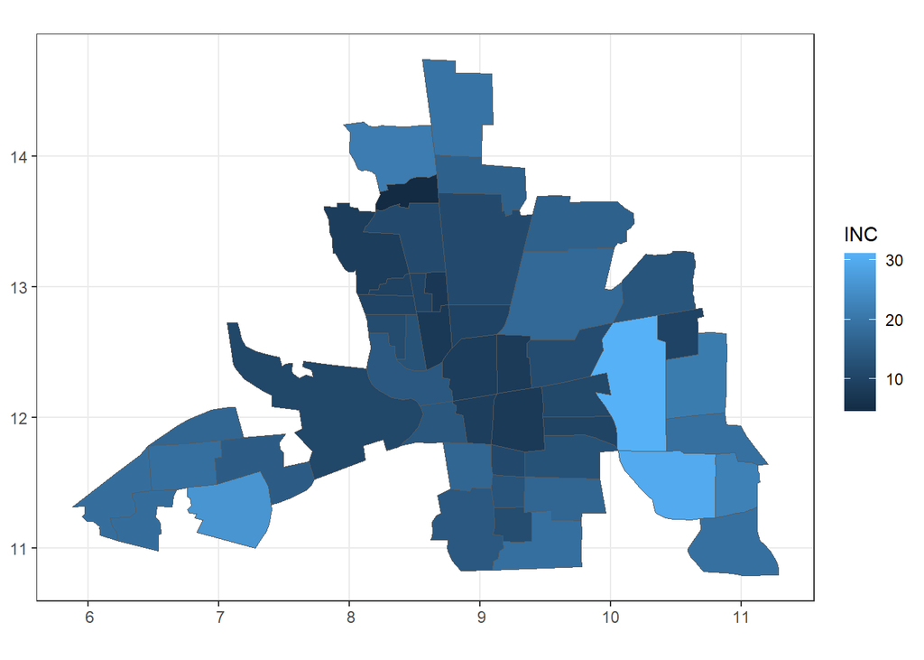

```r
library(ggplot2)
d <- st_read(system.file("shapes/columbus.shp", package = "spData"), quiet = TRUE)
ggplot(d) + geom_sf(aes(fill = INC))
```

```r
library(terra)
```

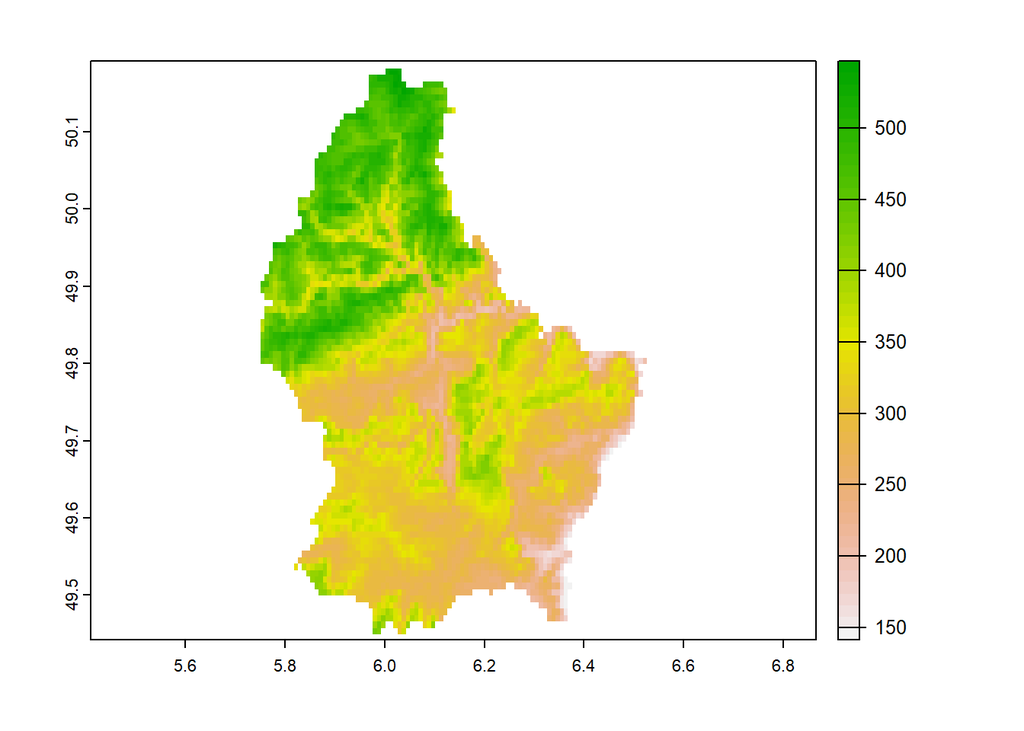

```r
d <- rast(system.file("ex/elev.tif", package = "terra"))
plot(d)
```

Best packages to use with raster data: + `sf` + `terra`

## 2.2 Geostatistical data

- Specific (fixed) monitoring points at fixed locations
- data from the `sp` package

```r
library(sp)
library(sf)
library(mapview)

data(meuse)
meuse <- st_as_sf(meuse, coords = c("x", "y"), crs = 28992)
mapview(meuse, zcol = "lead",  map.types = "CartoDB.Voyager")
```

[interactive chart not shown]

```r
# mapview(properties, zcol = "prpsqm")
```

We are essentially measuring price per square meter (Euros/square meter) of a specific set of apartments in Athens, Greece, in 2017.

```r
library(malariaAtlas)
d <- getPR(country = "Zimbabwe", species = "BOTH")
```

```
## Creating list of countries for which MAP data is available, please wait...
```

```
## Confirming availability of PR data for: Zimbabwe...
```

```
## PR points are available for Zimbabwe.
```

```
## Attempting to download PR point data for Zimbabwe ...
```

```
## Data downloaded for Zimbabwe.
```

```
## NOTE: All available data for this query was downloaded for both species,
##  but there are no PR points for P. vivax in this region in the MAP database.
## To check endemicity patterns or to contribute data, visit malariaatlas.org OR email us at map@bdi.ox.ac.uk.
```

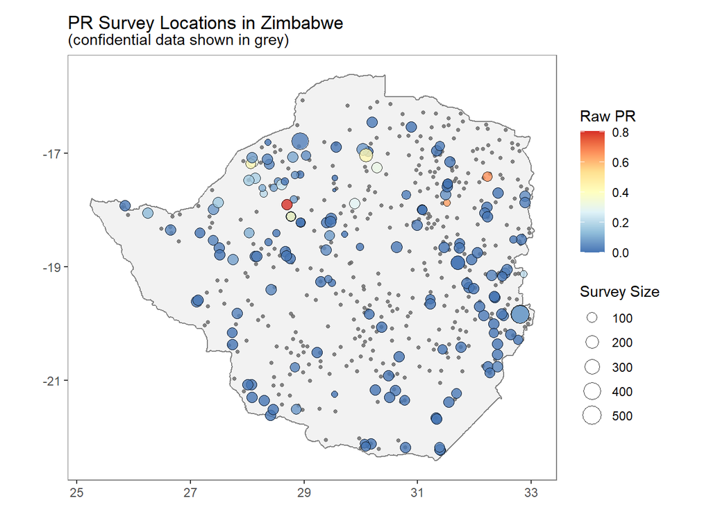

```r
autoplot(d)
```

## 2.3 Point patterns

- Data points that arise at random Examples:
  - fires
  - diseases
- data from `spatstat.data` package

```r
library(spatstat)
```

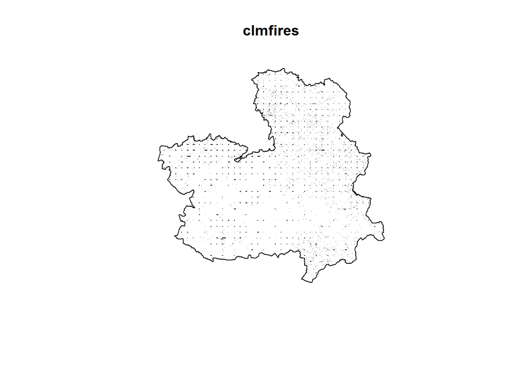

```r
# plot(spatstat.data::bdspots)
plot(clmfires, use.marks = FALSE, pch = ".")
```

- We could estimate the intensity of fires for example

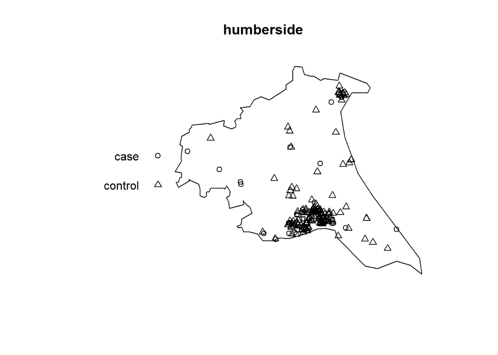

```r
plot(humberside)
```

- Look into clusters and infer on the results

# 3 Spatio-temporal data

```r
devtools::install_github("Paula-Moraga/SpatialEpiApp")
```

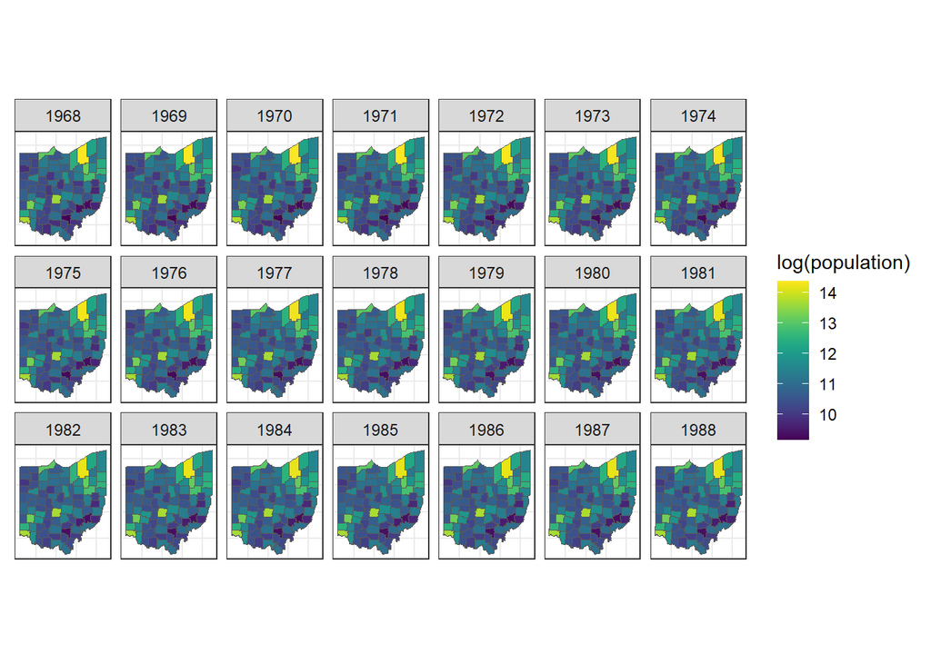

```r
library(SpatialEpiApp)
library(sf)
library(ggplot2)
library(viridis)
# map
pathshp <- system.file("SpatialEpiApp/data/Ohio/fe_2007_39_county/fe_2007_39_county.shp",
package = "SpatialEpiApp")
map <- st_read(pathshp, quiet = TRUE)

# data
namecsv <- "SpatialEpiApp/data/Ohio/dataohiocomplete.csv"
d <- read.csv(system.file(namecsv, package = "SpatialEpiApp"))

# data are disaggregated by gender and race
# aggregate to get population in each county and year
d <- aggregate(x = d$n, by = list(county = d$NAME, year = d$year), FUN = sum)
names(d) <- c("county", "year", "population")

# join map and data
mapst <- dplyr::left_join(map, d, by = c("NAME" = "county"))

# map population by year
# facet_wrap() splits the data into subsets and create multiple plots
ggplot(mapst, aes(fill = log(population))) + geom_sf() +
  facet_wrap(~ year, ncol = 7) + scale_fill_viridis("log(population)") +
  theme(axis.text.x = element_blank(), axis.text.y = element_blank(), axis.ticks = element_blank())
```

# 4 Spatial functional data

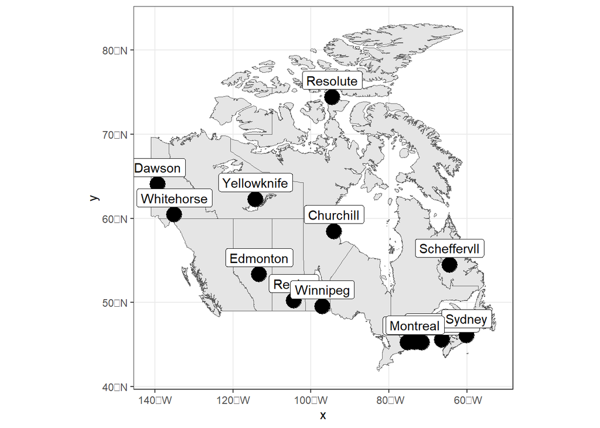

```r
library(sf)
library(mapview)
library(geoFourierFDA)
library(rnaturalearth)
# Map Canada
map <- rnaturalearth::ne_states("Canada", returnclass = "sf")

# Coordinates of stations
d <- data.frame(canada$m_coord)
d$location <- attr(canada$m_coord, "dimnames")[[1]]
d <- st_as_sf(d, coords = c("W.longitude", "N.latitude"))
st_crs(d) <- 4326

# Plot Canada map and location of stations
ggplot(map) + geom_sf() + geom_sf(data = d, size = 6) +
  geom_sf_label(data = d, aes(label = location), nudge_y = 2)
```

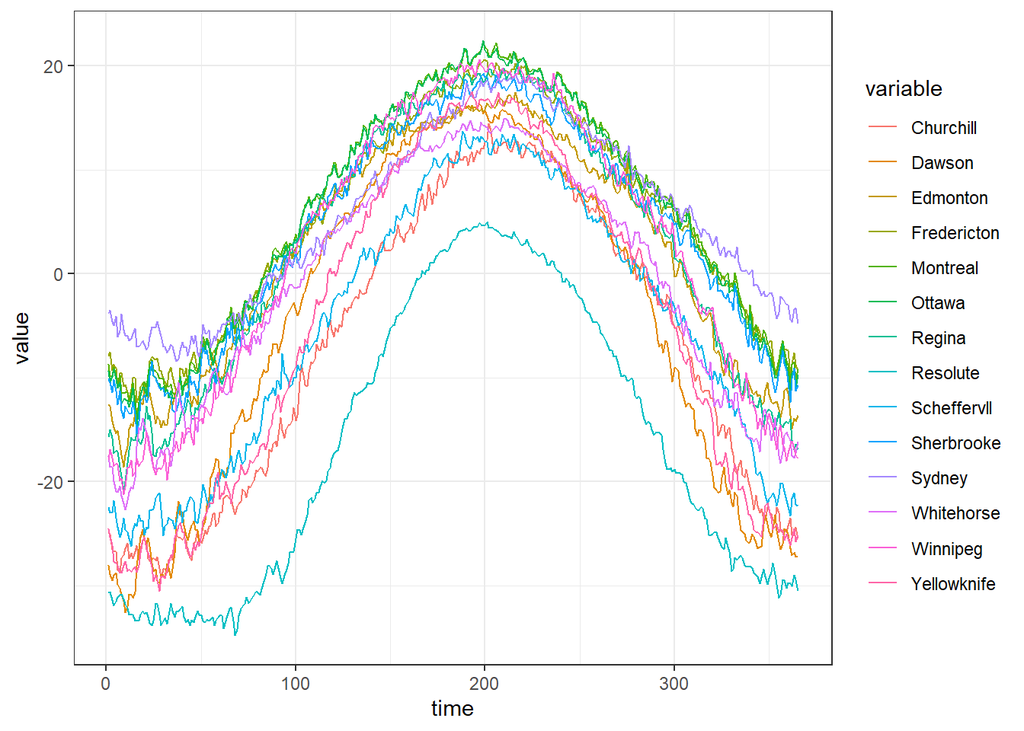

```r
# Temperature of each station over time
d <- data.frame(canada$m_data)
d$time <- 1:nrow(d)

# Pivot data d from wide to long
df <- tidyr::pivot_longer(data = d,
                   cols = names(d)[-which(names(d) == "time")], # columns to pivot into longer format
                   names_to = "variable", # name of the new column with the column names of the original data
                   values_to = "value") # name of the new column with the values of the original data

# Plot temperature of each station over time
ggplot(df, aes(x = time, y = value)) + geom_line(aes(color = variable))
```

# 5 Spatial data in R

- [link](https://www.paulamoraga.com/book-gds/22-spatial-spatialdatainR.html)

## 5.1 Vector data

- `sf` package is the one we use here

### 5.1.1 Shapefile

Vector spatial data such as points, lines and polygons are often represented using a data storage format called shapefile. A shapefile is not a single file but a collection of related files. A shapefile has three mandatory files:

- `shp`: contains the geometry data,
- `shx`: positional index of the geometry data that allows to seek forwards and backwards the .shp file,
- `dbf`: stores the attributes for each shape.

Other files that can form a shapefile include the following:

- `prj`: plain text file describing the projection,
- `sbn` and .sbx: spatial index of the geometry data,
- `shp.xml`: geospatial metadata in XML format.

Therefore, when working with a shapefile, it is important to obtain all files that compose the shapefile and not only the .shp file with the geometry data.

```r
library(sf)

# we are reading everything
pathshp <- system.file("shape/nc.shp", package = "sf")

map <- st_read(pathshp, quiet = TRUE)

class(map)
```

```
## [1] "sf"         "data.frame"
```

```r
head(map)
```

```
## Simple feature collection with 6 features and 14 fields
## Geometry type: MULTIPOLYGON
## Dimension:     XY
## Bounding box:  xmin: -81.74107 ymin: 36.07282 xmax: -75.77316 ymax: 36.58965
## Geodetic CRS:  NAD27
##    AREA PERIMETER CNTY_ CNTY_ID        NAME  FIPS FIPSNO CRESS_ID BIR74 SID74
## 1 0.114     1.442  1825    1825        Ashe 37009  37009        5  1091     1
## 2 0.061     1.231  1827    1827   Alleghany 37005  37005        3   487     0
## 3 0.143     1.630  1828    1828       Surry 37171  37171       86  3188     5
## 4 0.070     2.968  1831    1831   Currituck 37053  37053       27   508     1
## 5 0.153     2.206  1832    1832 Northampton 37131  37131       66  1421     9
## 6 0.097     1.670  1833    1833    Hertford 37091  37091       46  1452     7
##   NWBIR74 BIR79 SID79 NWBIR79                       geometry
## 1      10  1364     0      19 MULTIPOLYGON (((-81.47276 3...
## 2      10   542     3      12 MULTIPOLYGON (((-81.23989 3...
## 3     208  3616     6     260 MULTIPOLYGON (((-80.45634 3...
## 4     123   830     2     145 MULTIPOLYGON (((-76.00897 3...
## 5    1066  1606     3    1197 MULTIPOLYGON (((-77.21767 3...
## 6     954  1838     5    1237 MULTIPOLYGON (((-76.74506 3...
```

- The *geometry* column gives the shape

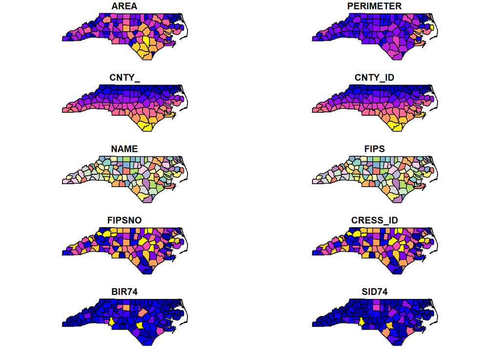

```r
plot(map)
```

## 5.2 Raster data

To work with regions, divided into rectangles/squares

We use - `raster` package (old one) - [`terra`](https://rspatial.org/terra) is the new package (the one we shold use) - [link](https://rspatial.org/pkg/index.html)

### 5.2.1 GeoTIFF

```r
library(terra)
pathraster <- system.file("ex/elev.tif", package = "terra")
r <- terra::rast(pathraster)
r
```

```
## class       : SpatRaster
## dimensions  : 90, 95, 1  (nrow, ncol, nlyr)
## resolution  : 0.008333333, 0.008333333  (x, y)
## extent      : 5.741667, 6.533333, 49.44167, 50.19167  (xmin, xmax, ymin, ymax)
## coord. ref. : lon/lat WGS 84 (EPSG:4326)
## source      : elev.tif
## name        : elevation
## min value   :       141
## max value   :       547
```

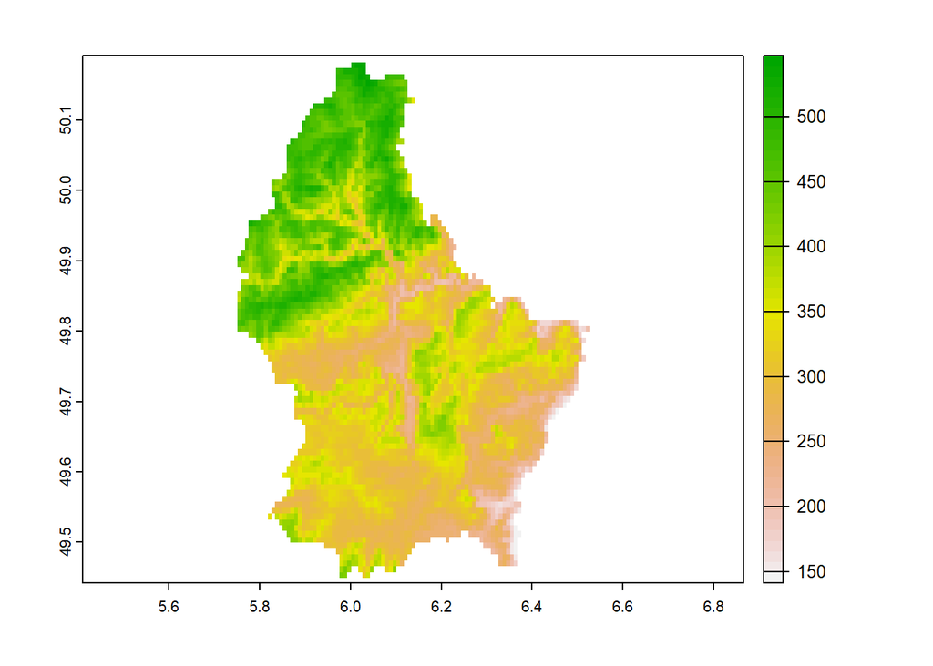

```r
plot(r)
```

## 5.3 Coordinate Reference Systems (CRS)

### 5.3.1 CRS with R

- `sf::st_crs()`
- `terra::crs()`

```r
library(sf)
pathshp <- system.file("shape/nc.shp", package = "sf")
map <- st_read(pathshp, quiet = TRUE)

# Get CRS
# st_crs(map)
# Transform CRS
map2 <- st_transform(map, crs = "EPSG:4326")
# Get CRS
# st_crs(map2)
```

# 6 Follow up exercise

## 6.1 Joining data

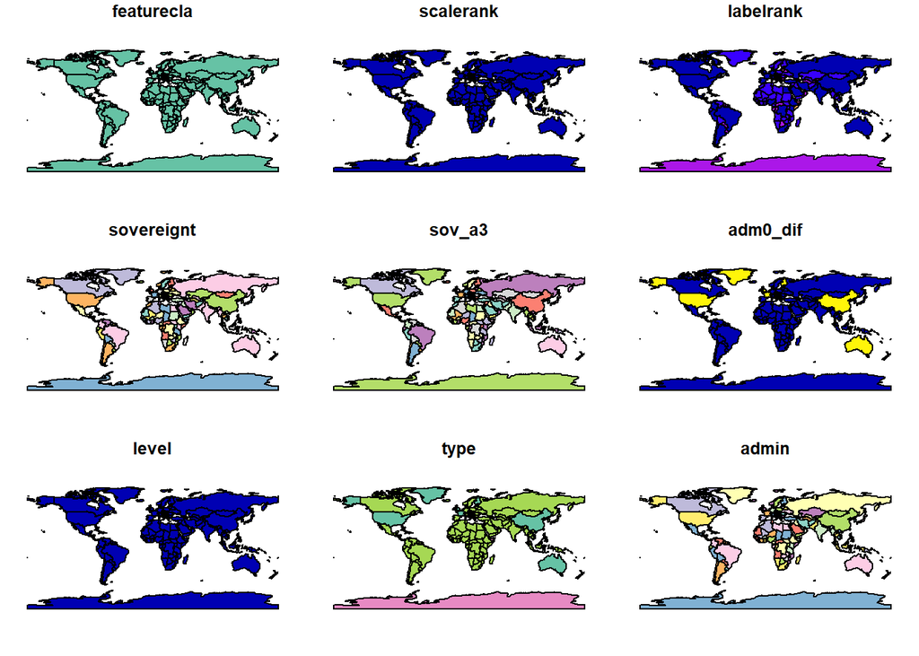

```r
# Map
library(rnaturalearth)
map <- ne_countries(returnclass = "sf")
plot(map)
```

- `wbstats` package has indicators for each country

```r
# Download data from each of the countries
library(wbstats)
# determine pattern
indicators <- wb_search(pattern = "pollution")
d <- wb_data(indicator = "EN.ATM.PM25.MC.M3", start_date = 2016, end_date = 2016)
head(d)
```

```
## # A tibble: 6 × 9
##   iso2c iso3c country              date EN.AT…¹ unit  obs_s…² footn…³ last_upd…⁴
##   <chr> <chr> <chr>               <dbl>   <dbl> <chr> <chr>   <chr>   <date>
## 1 AW    ABW   Aruba                2016    NA   <NA>  <NA>    <NA>    2023-03-01
## 2 AF    AFG   Afghanistan          2016    56.3 <NA>  <NA>    <NA>    2023-03-01
## 3 AO    AGO   Angola               2016    31.8 <NA>  <NA>    <NA>    2023-03-01
## 4 AL    ALB   Albania              2016    18.2 <NA>  <NA>    <NA>    2023-03-01
## 5 AD    AND   Andorra              2016    10.3 <NA>  <NA>    <NA>    2023-03-01
## 6 AE    ARE   United Arab Emirat…  2016    40.5 <NA>  <NA>    <NA>    2023-03-01
## # … with abbreviated variable names ¹EN.ATM.PM25.MC.M3, ²obs_status, ³footnote,
## #   ⁴last_updated
```

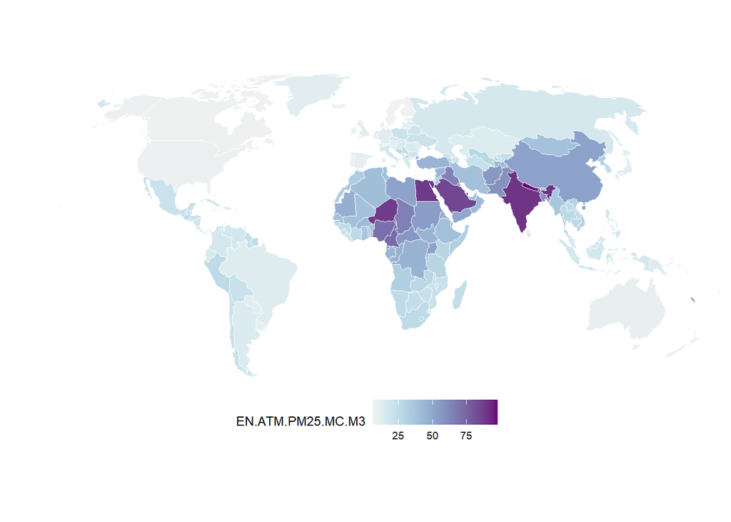

```r
# Join
# library(dplyr)
# map1 <- left_join(map, d, by = c("iso_a3" = "iso3c"))
map1 <- merge(map, d, by.x = "iso_a3", by.y = "iso3c")

# Plot
library(ggplot2)
library(viridis)
library(ggthemes)
ggplot(map1) +
  geom_sf(aes(fill = EN.ATM.PM25.MC.M3), color = "white") +
  colorspace::scale_fill_continuous_sequential(palette = "Purple-Blue") +
  # scale_fill_viridis() +
  theme_map() +
  theme(
    legend.position = "bottom",
    legend.justification = "center"
  ) +
  # guides(fill = guide_legend(title.position = "top")) +
  coord_sf(crs = "+proj=robin", expand = FALSE)
```

# 7 Areal data (follow up)

## 7.1 Spatial risk modelling

- [link](https://www.paulamoraga.com/book-gds/34-arealdata-modeling-example.html#Spatial_modeling_of_disease_risk_using_areal_data)
- [Example](https://www.envhealthatlas.co.uk/eha/Lung/) used in this exercise to see the geographical patterns of female lung cancer in the UK
  - it compares the risk *relatively* to the overall risk (absolute) of the country
- [Example 2](https://atlas.cancer.org.au/app)

## 7.2 Spatial modeling of risk of lung cancer in Pennsylvania

### 7.2.1 Data and map

```r
library(SpatialEpi)
# load the data
data(pennLC)
class(pennLC)
```

```
## [1] "list"
```

```r
head(pennLC$geo)
```

```
##      county         x        y
## 1     adams -77.21550 39.87776
## 2 allegheny -79.97980 40.46986
## 3 armstrong -79.46558 40.81654
## 4    beaver -80.34774 40.68327
## 5   bedford -78.48906 40.01033
## 6     berks -75.92717 40.41920
```

```r
# data of interest
head(pennLC$data)
```

```
##   county cases population race gender      age
## 1  adams     0       1492    o      f Under.40
## 2  adams     0        365    o      f    40.59
## 3  adams     1         68    o      f    60.69
## 4  adams     0         73    o      f      70+
## 5  adams     0      23351    w      f Under.40
## 6  adams     5      12136    w      f    40.59
```

```r
# proportions
head(pennLC$smoking)
```

```
##      county smoking
## 1     adams   0.234
## 2 allegheny   0.245
## 3 armstrong   0.250
## 4    beaver   0.276
## 5   bedford   0.228
## 6     berks   0.249
```

```r
# spetial polygon with counties of Pensilvania
pennLC$spatial.polygon
```

```
## class       : SpatialPolygons
## features    : 67
## extent      : -80.53494, -74.72516, 39.72316, 42.26137  (xmin, xmax, ymin, ymax)
## crs         : +proj=longlat
```

`pennLC$spatial.polygon` is from package `sp`, we need to transform it into a `sf` file (function *st_as_sf()*)

```r
library(sf)
map <- st_as_sf(pennLC$spatial.polygon)
countynames <- sapply(slot(pennLC$spatial.polygon, "polygons"), function(x){slot(x, "ID")})
```

```r
map$county <- countynames
head(map)
```

```
## Simple feature collection with 6 features and 1 field
## Geometry type: POLYGON
## Dimension:     XY
## Bounding box:  xmin: -80.51776 ymin: 39.72889 xmax: -75.53303 ymax: 41.1441
## Geodetic CRS:  +proj=longlat
##                         geometry    county
## 1 POLYGON ((-77.4467 39.96954...     adams
## 2 POLYGON ((-80.14534 40.6742... allegheny
## 3 POLYGON ((-79.21142 40.9091... armstrong
## 4 POLYGON ((-80.1568 40.85189...    beaver
## 5 POLYGON ((-78.38063 39.7288...   bedford
## 6 POLYGON ((-75.53303 40.4508...     berks
```

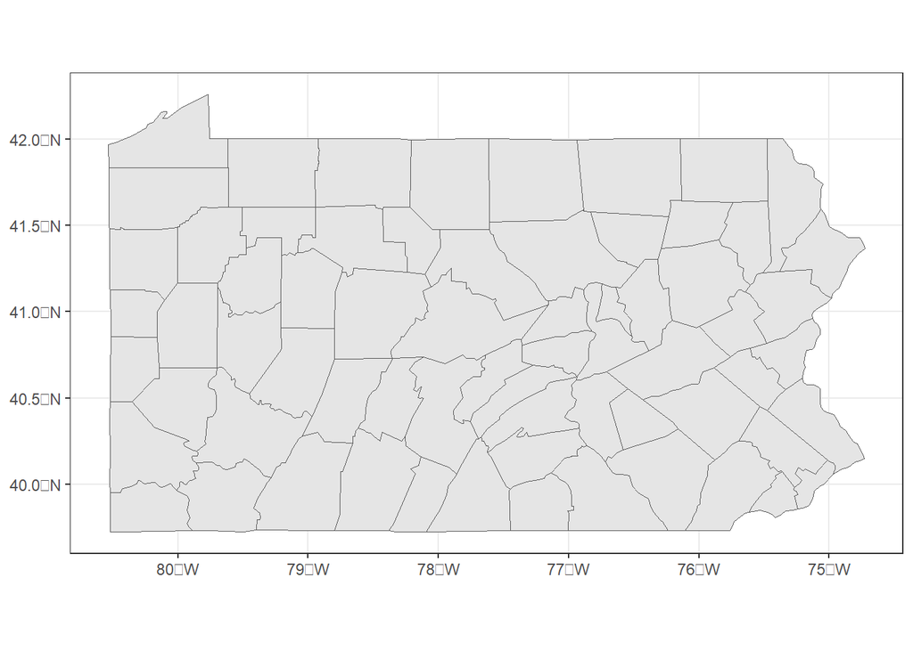

```r
library(ggplot2)
ggplot(map) + geom_sf()
```

### 7.2.2 Observed cases

```r
library(dplyr)
# add the observed number of cases
d <- group_by(pennLC$data, county) %>% summarize(Y = sum(cases))
head(d)
```

```
## # A tibble: 6 × 2
##   county        Y
##   <fct>     <int>
## 1 adams        55
## 2 allegheny  1275
## 3 armstrong    49
## 4 beaver      172
## 5 bedford      37
## 6 berks       308
```

### 7.2.3 Expected cases

We can now calculate the expected number of cases

```r
pennLC$data <- pennLC$data[order(pennLC$data$county, pennLC$data$race, pennLC$data$gender, pennLC$data$age), ]
```

- The **number of strata** is set to 16 since there are 2 races, 2 genders and 4 age groups for each county ($2 \times 2 \times 4 = 16$).

```r
# from package SpatialEpi
E <- expected(population = pennLC$data$population,
              cases = pennLC$data$cases,
              n.strata = 16)
E
```

```
##  [1]   69.627305 1182.428036   67.610123  172.558055   44.190132  300.705979
##  [7]  115.069655   53.237644  428.797481  134.797705  149.846027    5.945905
## [13]   55.475211   79.404013  300.124058   33.906647   73.853240   33.012029
## [19]   53.312111   75.025024  170.866603  199.809038  454.545971   31.543736
## [25]  216.203436  137.810484    5.403583  109.888662   11.594802   33.093112
## [31]   36.659515   71.090130   42.555800   18.735146  204.172754  357.237966
## [37]   91.303056  103.076598  259.874790  309.688036  101.231639   40.105227
## [43]  111.790653   40.774630  100.094714  608.691819   16.081330  222.731099
## [49]   90.872134   31.037254 1219.102696   39.865269   16.003210  147.937712
## [55]   28.878902   74.523497    7.419682   36.174266   35.756382   30.833836
## [61]   51.141014   39.230710  189.097720   44.490161  351.175955   21.009224
## [67]  288.869666
```

```r
d$E <- E

head(d)
```

```
## # A tibble: 6 × 3
##   county        Y      E
##   <fct>     <int>  <dbl>
## 1 adams        55   69.6
## 2 allegheny  1275 1182.
## 3 armstrong    49   67.6
## 4 beaver      172  173.
## 5 bedford      37   44.2
## 6 berks       308  301.
```

### 7.2.4 Effect of smoking (Smokers proportion)

Adding the smoking data (proportions) into the dataset

```r
d <- left_join(d, pennLC$smoking, by = "county")
```

### 7.2.5 Standardized Mortality Ratios

Estimate the Standardized Mortality Ratios

```r
d$SMR <- d$Y/d$E

head(d)
```

```
## # A tibble: 6 × 5
##   county        Y      E smoking   SMR
##   <fct>     <int>  <dbl>   <dbl> <dbl>
## 1 adams        55   69.6   0.234 0.790
## 2 allegheny  1275 1182.    0.245 1.08
## 3 armstrong    49   67.6   0.25  0.725
## 4 beaver      172  173.    0.276 0.997
## 5 bedford      37   44.2   0.228 0.837
## 6 berks       308  301.    0.249 1.02
```

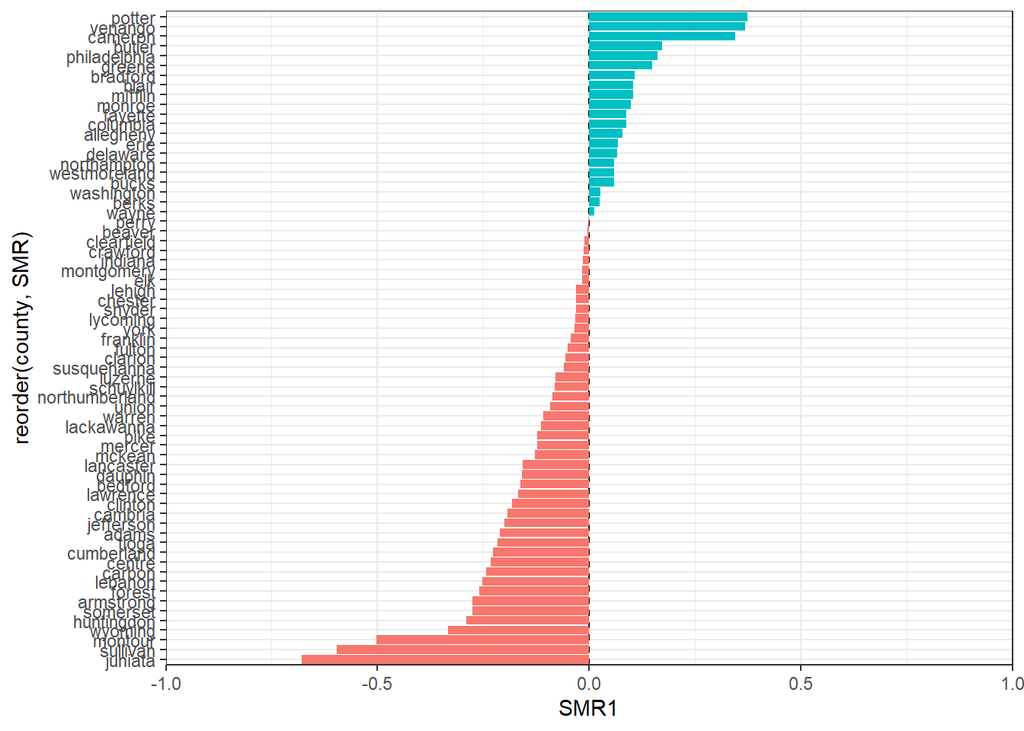

```r
d %>%
  mutate(SMR1 = SMR-1) %>%
  ggplot(aes(SMR1, reorder(county, SMR))) +
  geom_vline(xintercept = 0, lty = 2) +
  geom_col(aes(fill = SMR1 > 0)) +
  scale_x_continuous(limits = c(-1, 1), expand = expansion(0,0)) +
  theme_bw() +
  theme(
    legend.position = "none"
  )
```

### 7.2.6 Mapping SMR

```r
library(dplyr)
map <- left_join(map, d, by = "county")
head(map)
```

```
## Simple feature collection with 6 features and 5 fields
## Geometry type: POLYGON
## Dimension:     XY
## Bounding box:  xmin: -80.51776 ymin: 39.72889 xmax: -75.53303 ymax: 41.1441
## Geodetic CRS:  +proj=longlat
##      county    Y          E smoking       SMR                       geometry
## 1     adams   55   69.62730   0.234 0.7899200 POLYGON ((-77.4467 39.96954...
## 2 allegheny 1275 1182.42804   0.245 1.0782897 POLYGON ((-80.14534 40.6742...
## 3 armstrong   49   67.61012   0.250 0.7247435 POLYGON ((-79.21142 40.9091...
## 4    beaver  172  172.55806   0.276 0.9967660 POLYGON ((-80.1568 40.85189...
## 5   bedford   37   44.19013   0.228 0.8372910 POLYGON ((-78.38063 39.7288...
## 6     berks  308  300.70598   0.249 1.0242563 POLYGON ((-75.53303 40.4508...
```

```r
library(mapview)
library(RColorBrewer)
pal <- colorRampPalette(brewer.pal(9, "YlOrRd"))
pal <- colorspace::sequential_hcl(palette = "Blu-Yl", n = 50)

mapview(
  map,
  zcol = "SMR",
  color = "white",
  alpha.regions = 0.8,
  layer.name = "SMR",
  col.regions = pal,
  map.types = "CartoDB.Positron"
)
```

[interactive chart not shown]

- We can personalise the map to show certain options only

```r
library(mapview)
library(RColorBrewer)
library(leafpop)
pal <- colorRampPalette(brewer.pal(9, "YlOrRd"))
mapviewOptions(fgb = FALSE)

popuptable <-
  leafpop::popupTable(
    dplyr::mutate_if(map, is.numeric, round, digits = 2),
    zcol = c("county", "Y", "E", "smoking", "SMR"),
    row.numbers = FALSE,
    feature.id = FALSE
  )
mapview(
  map,
  zcol = "SMR",
  color = "gray",
  col.regions = pal,
  highlight = leaflet::highlightOptions(weight = 4),
  popup = popuptable
)
```

[interactive chart not shown]

### 7.2.7 Modelling

- Smooth analysis
- uncertainty associated to the covs of the risk

Let $Y_i$ and $E_i$ be the observed and expected number of disease cases, respectively, and let $\theta_i$ be the relative risk for county $i=1,.,n$. The model is specified as follows:

$$Y_i|\theta_i \sim Poisson(E_i\times \theta_i), i=1,.,n,$$

$$\log(\theta_i) = \beta_0 + \beta_1 \times smoking_i + u_i + v_i$$

### 7.2.8 Neighbourhood matrix

```r
library(spdep)
library(INLA)
```

```r
nb <- poly2nb(map)
head(nb)
```

```
## [[1]]
## [1] 21 28 67
##
## [[2]]
## [1]  3  4 10 63 65
##
## [[3]]
## [1]  2 10 16 32 33 65
##
## [[4]]
## [1]  2 10 37 63
##
## [[5]]
## [1]  7 11 29 31 56
##
## [[6]]
## [1] 15 36 38 39 46 54
```

```r
nb2INLA("map.adj", nb)
g <- inla.read.graph(filename = "map.adj")
```

### 7.2.9 Inference using `INLA`

```r
map$re_u <- 1:nrow(map)
map$re_v <- 1:nrow(map)
```

```r
formula <- Y ~ smoking + f(re_u, model = "besag", graph = g, scale.model = TRUE) + f(re_v, model = "iid")
# besag is the conditional autorregressive model
```

Then, we fit the model using the *inla()* function with the default priors in `INLA`. We specify the *formula*, *family*, *data*, and the expected counts ( *E* ), and set *control.predictor = list(compute = TRUE)* and *control.compute = list(return.marginals.predictor = TRUE)* to compute the posterior means of the predictors.

```r
# results
res <- inla(
  formula,
  family = "poisson",
  data = map,
  E = E,
  control.predictor = list(compute = TRUE),
  control.compute = list(return.marginals.predictor = TRUE)
)
```

### 7.2.10 Results

```r
summary(res)
```

```
##
## Call:
##    c("inla.core(formula = formula, family = family, contrasts = contrasts,
##    ", " data = data, quantiles = quantiles, E = E, offset = offset, ", "
##    scale = scale, weights = weights, Ntrials = Ntrials, strata = strata,
##    ", " lp.scale = lp.scale, link.covariates = link.covariates, verbose =
##    verbose, ", " lincomb = lincomb, selection = selection, control.compute
##    = control.compute, ", " control.predictor = control.predictor,
##    control.family = control.family, ", " control.inla = control.inla,
##    control.fixed = control.fixed, ", " control.mode = control.mode,
##    control.expert = control.expert, ", " control.hazard = control.hazard,
##    control.lincomb = control.lincomb, ", " control.update =
##    control.update, control.lp.scale = control.lp.scale, ", "
##    control.pardiso = control.pardiso, only.hyperparam = only.hyperparam,
##    ", " inla.call = inla.call, inla.arg = inla.arg, num.threads =
##    num.threads, ", " blas.num.threads = blas.num.threads, keep = keep,
##    working.directory = working.directory, ", " silent = silent, inla.mode
##    = inla.mode, safe = FALSE, debug = debug, ", " .parent.frame =
##    .parent.frame)")
## Time used:
##     Pre = 2.04, Running = 0.432, Post = 0.309, Total = 2.78
## Fixed effects:
##               mean    sd 0.025quant 0.5quant 0.975quant   mode kld
## (Intercept) -0.324 0.150     -0.619   -0.323     -0.029 -0.323   0
## smoking      1.155 0.622     -0.075    1.156      2.378  1.160   0
##
## Random effects:
##   Name     Model
##     re_u Besags ICAR model
##    re_v IID model
##
## Model hyperparameters:
##                        mean       sd 0.025quant 0.5quant 0.975quant    mode
## Precision for re_u   231.16   123.93      77.05   203.32     549.35  158.08
## Precision for re_v 18056.42 18066.74    1152.27 12555.31   66244.79 3120.58
##
## Marginal log-Likelihood:  -289.45
##  is computed
## Posterior summaries for the linear predictor and the fitted values are computed
## (Posterior marginals needs also 'control.compute=list(return.marginals.predictor=TRUE)')
```

```r
# look at the estimated risks
res$summary.fitted.values
```

```
##                          mean         sd 0.025quant  0.5quant 0.975quant
## fitted.Predictor.01 0.8781523 0.05795777  0.7650061 0.8779424  0.9933101
## fitted.Predictor.02 1.0595685 0.02748605  1.0071286 1.0590562  1.1149049
## fitted.Predictor.03 0.9655921 0.05032064  0.8632547 0.9666167  1.0624215
## fitted.Predictor.04 1.0274973 0.05088827  0.9292136 1.0268597  1.1296648
## fitted.Predictor.05 0.9065921 0.05409117  0.7999072 0.9066867  1.0135568
## fitted.Predictor.06 0.9938142 0.03985520  0.9180358 0.9928826  1.0750041
## fitted.Predictor.07 0.9553357 0.05030052  0.8625431 0.9530754  1.0612370
## fitted.Predictor.08 0.9742939 0.05883212  0.8634341 0.9725178  1.0959308
## fitted.Predictor.09 1.0375781 0.03966224  0.9631076 1.0363765  1.1187696
## fitted.Predictor.10 1.0528436 0.04641744  0.9666752 1.0509738  1.1497608
## fitted.Predictor.11 0.9265062 0.04418483  0.8373592 0.9273368  1.0112002
## fitted.Predictor.12 0.9424845 0.06094369  0.8275397 0.9405262  1.0693428
## fitted.Predictor.13 0.9305170 0.05090383  0.8295496 0.9306902  1.0310289
## fitted.Predictor.14 0.8852377 0.04617893  0.7938243 0.8854375  0.9759629
## fitted.Predictor.15 0.9717079 0.04102871  0.8932619 0.9709068  1.0547895
## fitted.Predictor.16 0.9618509 0.05786587  0.8513056 0.9604829  1.0805889
## fitted.Predictor.17 0.9368318 0.04485940  0.8505662 0.9360659  1.0279062
## fitted.Predictor.18 0.9613822 0.05601731  0.8520604 0.9610307  1.0735066
## fitted.Predictor.19 0.9113618 0.05080162  0.8159091 0.9096842  1.0169466
## fitted.Predictor.20 1.0176531 0.06039081  0.9025332 1.0162916  1.1408735
## fitted.Predictor.21 0.8463121 0.04389961  0.7597786 0.8464771  0.9322163
## fitted.Predictor.22 0.8717570 0.03814319  0.7965705 0.8718825  0.9465560
## fitted.Predictor.23 1.0522491 0.04035206  0.9760690 1.0511741  1.1344660
## fitted.Predictor.24 0.9469501 0.05526498  0.8414228 0.9456630  1.0603185
## fitted.Predictor.25 1.0467128 0.05701214  0.9399524 1.0448828  1.1638630
## fitted.Predictor.26 1.0216619 0.05493771  0.9205055 1.0191809  1.1366986
## fitted.Predictor.27 0.9530231 0.05837472  0.8412778 0.9517033  1.0727737
## fitted.Predictor.28 0.9066720 0.04664297  0.8167204 0.9060734  1.0006596
## fitted.Predictor.29 0.9110507 0.06927373  0.7778565 0.9098824  1.0523381
## fitted.Predictor.30 1.0437881 0.08535297  0.8908438 1.0383146  1.2274581
## fitted.Predictor.31 0.8977955 0.04887700  0.8006629 0.8981352  0.9936563
## fitted.Predictor.32 0.9710334 0.05195447  0.8702985 0.9704286  1.0758016
## fitted.Predictor.33 0.9348448 0.05264304  0.8310293 0.9348207  1.0393725
## fitted.Predictor.34 0.8850978 0.05216920  0.7803463 0.8858244  0.9864287
## fitted.Predictor.35 0.9384379 0.04638538  0.8482242 0.9381632  1.0304943
## fitted.Predictor.36 0.8778556 0.03665476  0.8060082 0.8778564  0.9498984
## fitted.Predictor.37 0.9697560 0.06229721  0.8466084 0.9700759  1.0916729
## fitted.Predictor.38 0.8656443 0.04968157  0.7662904 0.8663017  0.9617677
## fitted.Predictor.39 0.9788157 0.03920460  0.9033443 0.9781868  1.0579618
```

[output cut: 81 more lines]

```
## fitted.Predictor.53 0.9819537
## fitted.Predictor.54 0.9431883
## fitted.Predictor.55 0.8913568
## fitted.Predictor.56 0.9342005
## fitted.Predictor.57 0.9507063
## fitted.Predictor.58 0.9186192
## fitted.Predictor.59 0.9472172
## fitted.Predictor.60 0.8942645
## fitted.Predictor.61 1.0473697
## fitted.Predictor.62 0.9534795
## fitted.Predictor.63 1.0131512
## fitted.Predictor.64 0.9377231
## fitted.Predictor.65 1.0084780
## fitted.Predictor.66 0.9365017
## fitted.Predictor.67 0.9239911
```

```r
map$RR <- res$summary.fitted.values[, "mean"] # relative risk
map$LL <- res$summary.fitted.values[, "0.025quant"] # lower limit 95% CI
map$UL <- res$summary.fitted.values[, "0.975quant"] # upper limit 95% CI

# plot(res)
```

### 7.2.11 Mapping disease risk

```r
library(mapview)
library(RColorBrewer)
library(leafpop)
pal <- colorRampPalette(brewer.pal(9, "YlOrRd"))
mapviewOptions(fgb = FALSE)
mapview(
  map,
  zcol = "RR",
  color = "gray",
  col.regions = pal,
  highlight = leaflet::highlightOptions(weight = 4),
  popup = leafpop::popupTable(
    dplyr::mutate_if(map, is.numeric, round, digits = 2),
    zcol = c("county", "Y", "E", "smoking", "SMR", "RR", "LL", "UL"),
    row.numbers = FALSE,
    feature.id = FALSE
  )
)
```

[interactive chart not shown]

### 7.2.12 Comparing SMR and RR maps

```r
pal <- colorRampPalette(brewer.pal(9, "YlOrRd"))
at <- seq(min(map$SMR), max(map$SMR), length.out = 8)

m1 <- mapview(map, zcol = "SMR", color = "gray", col.regions = pal, at = at)
m2 <- mapview(map, zcol = "RR", color = "gray", col.regions = pal, at = at)
m <- leafsync::sync(m1, m2)
m
```

[interactive chart not shown]

All areal values have been smoothed into being closer to 1.

### 7.2.13 Exceedance probabilities

Question: What is the probability that the risk exceeds X?

```r
c <- 1.2
marg <- res$marginals.fitted.values[[51]]
# 1 - probability that the risk is less that c
1 - inla.pmarginal(q = c, marginal = marg)
```

```
## [1] 0.05613127
```

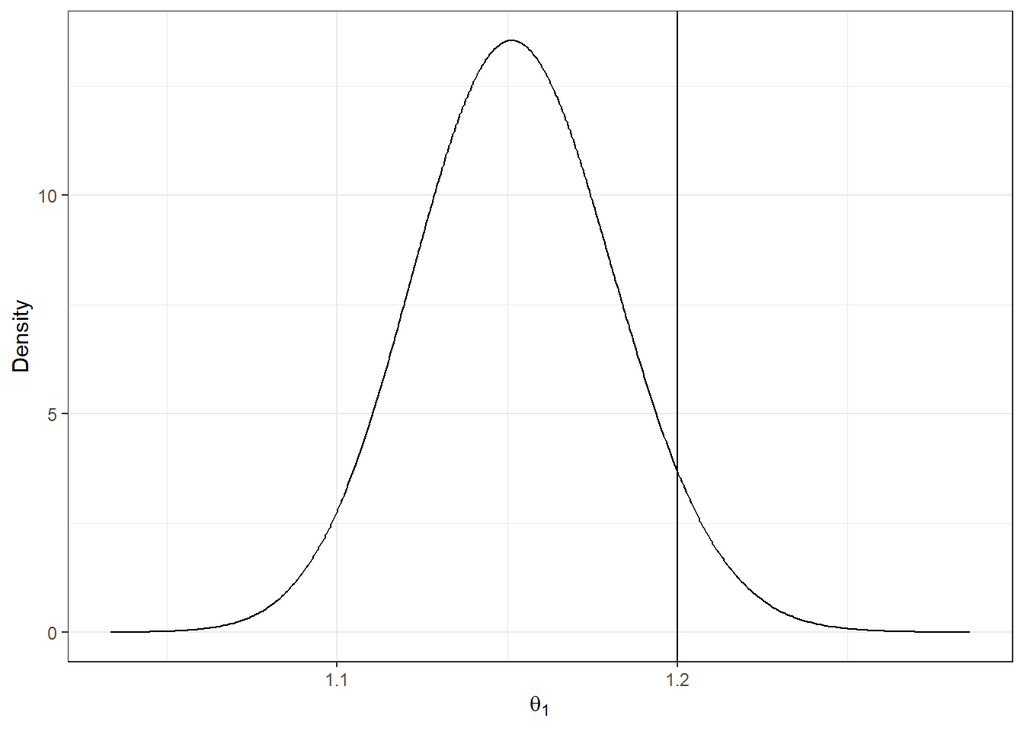

```r
library(ggplot2)
marginal <- inla.smarginal(res$marginals.fitted.values[[51]])
marginal <- data.frame(marginal)
ggplot(marginal, aes(x = x, y = y)) +
  geom_line() +
  labs(x = expression(theta[1]), y = "Density") +
  geom_vline(xintercept = 1.2, col = "black") +
  theme_bw()
```

```r
c <- 1.2
map$exc <- sapply(res$marginals.fitted.values,
FUN = function(marg){1 - inla.pmarginal(q = c, marginal = marg)})
```

```r
c <- 1.2
map$exc <- sapply(res$marginals.fitted.values,
FUN = function(marg){1 - inla.pmarginal(q = c, marginal = marg)})
```

```r
pal <- colorRampPalette(brewer.pal(9, "YlOrRd"))
mapview(map, zcol = "exc", color = "gray", col.regions = pal, map.types = "CartoDB.Positron")
```

[interactive chart not shown]

Answer: Not very likely that these areas will exceed 1.2.